# Customer Segmentation

# Introduction

In todays digital world a good understanding of customers is extremely important for running a succesful business. **Know your customer (KYC)** can make a huge difference in the margins of a company. It helps companies in creating, communicatinng and delivering their offerings by tailouring to their customer needs. Understanding customers and thier needs is not a trivial task and may include a studying a wide range of customer characteristics and their behaviour and numerous outcomes and performance indicators that business might be interested in. One of the most fundamental marketing strategy is segmentation, targeting and positioning. We are going to discuss Customer segmentation in more details below.

## What is Customer Segmentation?

Customer Segmentation (CS) is fundamental to every business. CS provides insight into the landscape of the market revealing customer characteristics that can be used to group customers into segments having something in common. It is also known as *Clustering*. Based on the characteristics of each cluster it is useful to assign meaningful name to that cluster. These labels help to summarize or characterize customers and can be used to design products, services or offers that provide innovative customer experiences.

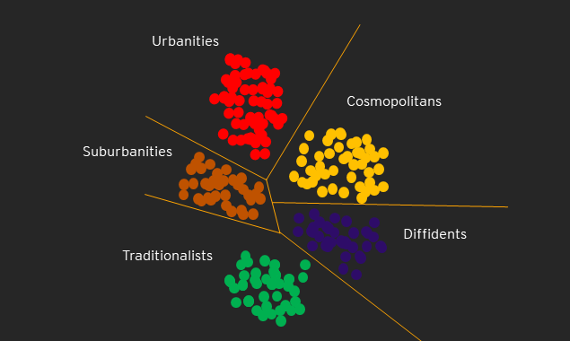

Customers clustered according to their characteristics

## Why and how to do Customer Segmentation analysis?

Customization makes customers happy which is great for the business and results in higher profits. The main objectives of CS anaysis are listed below:

1. To tailer the product or servics for each group of customers.
2. Identify best group of customers to sell product or services.
3. Create a successful marketing campaign.
4. To generate a report of underperfomring and overperforming segments.
5. To generate a new index that can be used in other ML models as a predictive variable.

Customers can be segmented using demographic (Age, Gender) or transactional information (Purchase history, Frequency) and can be analysed with cohort analysis or by running KMeans clustering.

### What is Cohort Analysis?

It is a descriptive analytics tool. It groups customers in mutually exclusive cohorts and provides deeper insights into customers patterns. There are different types of cohorts:

1. Time cohorts - monthly, quaterly or daily
2. Behaviour cohorts
3. Size cohorts

Let us load required libraries and read the Online Retail data to perform time- and behaviour-based cohort analysis. The data is derived from UCI repository.

```r
  library("readr")
  library("lubridate")
  library("dplyr")
  library("readxl")
  library("tidyr")
  library("DescTools")
```

```r
  library("gplots")
  library("ggplot2")
  library("caret")
  library("tibble")
  library("gridExtra")
  data <- read_excel("C:\\Users\\khannva1\\Documents\\DS-Projects\\Customer Segmentation\\OnlineRetail.xlsx")

  # Lets us remove the incomplete cases
  data <- data[complete.cases(data),]
```

```r
  # Begin the days from 01 in InvoiceMonth column
  # lubridate function parse_date_time and ymd().
  data <- data %>% mutate(InvoiceMonth = parse_date_time(paste(year(data$InvoiceDate),
                                                               month(data$InvoiceDate), sep = " "),
                                                         orders = c("Ym")) %>% ymd())

# Group by Customer Id and calcuate the smallest Inovice Month (when the customer was acquired)
  temp <- data %>% group_by(CustomerID) %>% select(CustomerID, InvoiceMonth) %>%
    summarise(CohortMonth = min(InvoiceMonth))

  data <- data %>% inner_join(temp, by = "CustomerID")

  # Calculate how many cohorts exist
  data <- data %>% mutate(invoice_year = year(InvoiceMonth), invoice_month = month(InvoiceMonth))
  data <- data %>% mutate(cohort_year = year(CohortMonth), cohort_month = month(CohortMonth))

  data <- data %>% mutate(years_diff = invoice_year - cohort_year)
  data <- data %>% mutate(months_diff = invoice_month - cohort_month)

  data <- data %>% mutate(CohortIndex = years_diff * 12 + months_diff + 1)
```

#### Time cohorts

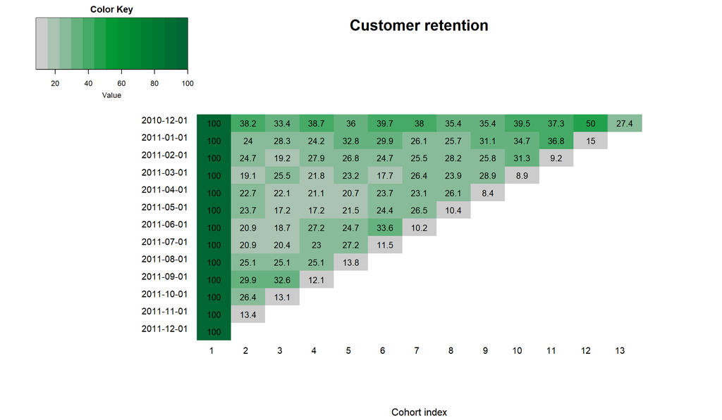

```r
  # Create the cohort table
  cohort_data <- data %>% group_by(CohortMonth,CohortIndex) %>% summarise(numCustomers = n_distinct(CustomerID))
  cohort_count <- cohort_data %>% spread(key = CohortIndex, value = numCustomers)

  # Calculate the retention
  cohort_sizes <- cohort_count[,2]
  # Divide the df with the row vector
  retention <- mapply('/',cohort_count[-1], cohort_count[,2]) %>%  round(3) * 100
  row.names(retention)<- cohort_count %>% pull(CohortMonth) %>% as.character()

  # Darw the heatmap
  colfunc <- colorRampPalette(c("#CCCCCC","#009933","#006633"))
  heatmap.2(retention, scale = "none", col = colfunc(13), trace = "none",
            density.info = "none", Rowv = NA, Colv = NA, dendrogram = "none",
            cellnote = retention, notecol = "black", xlab = "Cohort index",
            margins = c(8,8), sepcolor = "white",
            main = "Customer retention", adjRow = c(11,0), srtCol = 0)
```

Let us also plot quantity and value of goods purchased.

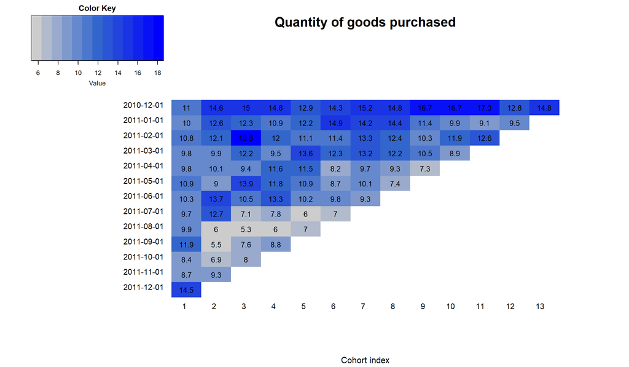

```r
  # Let us do the same thing for Quantity column to give us an idea of how our customers are spending
  cohort_data_quantity <- data %>% group_by(CohortMonth, CohortIndex) %>% summarise(avgQuantity = mean(Quantity))
  average_quantity <- cohort_data_quantity %>% spread(key = CohortIndex, value = avgQuantity)
  average_quantity_mat <- average_quantity[,-1] %>% as.matrix() %>% round(1)
  row.names(average_quantity_mat)<- average_quantity %>% pull(CohortMonth) %>% as.character()

  # Draw the heatmap
  colfunc <- colorRampPalette(c("#CCCCCC","#3366CC","#0000FF"))
  heatmap.2(average_quantity_mat, scale = "none", col = colfunc(13), trace = "none",
            density.info = "none", Rowv = NA, Colv = NA, dendrogram = "none",
            cellnote = average_quantity_mat, notecol = "black", xlab = "Cohort index",
            margins = c(8,8), sepcolor = "white",
            main = "Quantity of goods purchased", adjRow = c(11,0), srtCol = 0)
```

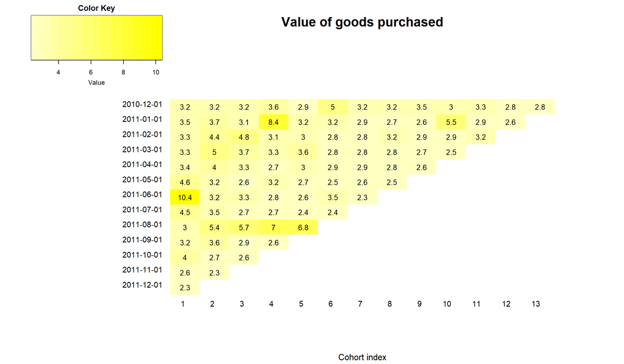

```r
# Let us do the same thing for UnitPrice column to give us an idea of how much our customers are spending
  cohort_data_unitprice <- data %>% group_by(CohortMonth, CohortIndex) %>% summarise(avgUnitPrice = mean(UnitPrice))
  average_unitprice <- cohort_data_unitprice %>% spread(key = CohortIndex, value = avgUnitPrice)
  average_unitprice_mat <- average_unitprice[,-1] %>% as.matrix() %>% round(1)
  row.names(average_unitprice_mat)<- average_unitprice %>% pull(CohortMonth) %>% as.character()

  # Draw the heatmap
  colfunc <- colorRampPalette(c("#FFFFC0","#FFFF66","#FFFF00"))
  heatmap.2(average_unitprice_mat, scale = "none", col = colfunc(13), trace = "none",
            density.info = "none", Rowv = NA, Colv = NA, dendrogram = "none",
            cellnote = average_unitprice_mat, notecol = "black", xlab = "Cohort index",sepcolor = "white",
            margins = c(8,8), main = "Value of goods purchased", adjRow = c(11,0), srtCol = 0)
```

### Behaviour based cohorts

1. Recency (R) - How recently did the customer did business with the company.
2. Frequency (F) - How many transactions the customer have done in the last 12 months.
3. Monetary Value (M) - How much did the customer spent during the last 12 months.

We will use these metrics to assign customers into *RFM segments*. This is help in analysing the behavioural patterns of our customers. For example if we filter on *RFM segment* 111 we see from the table below that there are 366 customers who have done no transaction with the business for quite a long time and might have churned.

```r
  # let us generate Spend column based on Quantity and Unit Price and
  # snapshot date from where we want to measure the recency of purchase
  data <- data %>% mutate(Spend = Quantity * UnitPrice)
  snapshot_date <- max(data$InvoiceMonth)
 # RFM
  datamart <- data %>% group_by(CustomerID) %>%
    mutate(MonetaryValue = sum(Spend), Recency = as.numeric(snapshot_date - max(InvoiceMonth)),
           Frequency = n()) %>% distinct(CustomerID, Recency, Frequency, MonetaryValue)
  labels <- seq(4,1)
  r_quantiles <- CutQ(datamart$Recency, breaks = quantile(datamart$Recency,
                                           seq(0,1, by = 0.25), na.rm = TRUE), labels = labels)

  # Frequency and recency are considered better if higher so labels change.
  labels <- seq(1,4)
  f_quantiles <- CutQ(datamart$Frequency, breaks = quantile(datamart$Frequency,
                                           seq(0,1, by = 0.25), na.rm = TRUE), labels = labels)
  m_quantiles <- CutQ(datamart$MonetaryValue, breaks = quantile(datamart$MonetaryValue,
                                          seq(0,1,by = 0.25), na.rm = TRUE),labels = labels)

  datamart <- datamart %>% add_column(R = r_quantiles, F = f_quantiles, M = m_quantiles)

  # Create RFM_Segment by combining R F and M values and RFM_Score by adding all three
  # First convert factor to character and then to numeric.
  datamart <- datamart %>% mutate_if(is.factor, as.character) %>%
    mutate(RFM_Segment = paste0(R,F,M)) %>%
    mutate_at(.,.vars = c('R','F','M'), as.numeric) %>%
    mutate(RFM_Score = sum(R,F,M)) %>% ungroup()

  # Select the customers at the bottom of the RFM_Segment
  datamart %>% filter(RFM_Segment == '111')
```

| CustomerID | Recency | Frequency | MonetaryValue | R | F | M | RFM_Segment | RFM_Score |
| --- | --- | --- | --- | --- | --- | --- | --- | --- |
| 17548 | 214 | 17 | -141.48 | 1 | 1 | 1 | 111 | 3 |
| 13747 | 365 | 1 | 79.60 | 1 | 1 | 1 | 111 | 3 |
| 12791 | 365 | 2 | 192.60 | 1 | 1 | 1 | 111 | 3 |
| 16583 | 365 | 14 | 233.45 | 1 | 1 | 1 | 111 | 3 |
| 14237 | 365 | 9 | 161.00 | 1 | 1 | 1 | 111 | 3 |
| 15350 | 365 | 5 | 115.65 | 1 | 1 | 1 | 111 | 3 |
| 17643 | 365 | 8 | 101.55 | 1 | 1 | 1 | 111 | 3 |
| 13065 | 365 | 14 | 205.86 | 1 | 1 | 1 | 111 | 3 |
| 12855 | 365 | 3 | 38.10 | 1 | 1 | 1 | 111 | 3 |
| 17855 | 365 | 17 | 208.97 | 1 | 1 | 1 | 111 | 3 |

[output cut: 356 more lines]

We can also use *RFM Score* to calculate the summary metrics of each group. For example

```r
datamart %>% group_by(RFM_Score) %>%
  summarise(meanRecency = mean(Recency), meanFrequency = mean(Frequency), meanMV = mean(MonetaryValue), countOfCustomers = n())
```

| RFM_Score | meanRecency | meanFrequency | meanMV | countOfCustomers |
| --- | --- | --- | --- | --- |
| 3 | 277.31148 | 7.811475 | 124.8436 | 366 |
| 4 | 202.76577 | 14.048048 | 212.3428 | 333 |
| 5 | 180.67198 | 21.168565 | 353.3545 | 439 |
| 6 | 100.68944 | 24.039337 | 437.4932 | 483 |
| 7 | 91.95980 | 36.396985 | 642.7185 | 398 |
| 8 | 68.36419 | 48.329980 | 863.1307 | 497 |
| 9 | 55.47696 | 69.113821 | 1201.7410 | 369 |
| 10 | 36.44211 | 90.585263 | 1483.6221 | 475 |
| 11 | 30.48794 | 144.750670 | 2562.8603 | 373 |
| 12 | 14.41315 | 340.154930 | 7869.0818 | 639 |

Grouping customers based on RFM_Score gives a good picture of behavioural patterns however, it is not uncommen to group customers into even samller groups of Gold, Silver and Bronze and calculate the summary statistics. For example

```r
datamart <- datamart %>% mutate(General_segment = case_when(RFM_Score >= 9 ~ "Gold",
                        RFM_Score >= 5 & RFM_Score < 9 ~ "Silver",
                        TRUE ~ "Bronze"))
datamart <- datamart %>% mutate(General_segment = factor(General_segment, levels = c("Gold", "Silver", "Bronze")))

datamart %>% group_by(General_segment) %>% summarise(meanRecency = mean(Recency), meanFrequency = mean(Frequency), meanMV = mean(MonetaryValue), countOfCustomers = n())
```

| General_segment | meanRecency | meanFrequency | meanMV | countOfCustomers |
| --- | --- | --- | --- | --- |
| Gold | 31.44558 | 183.12608 | 3842.9165 | 1856 |
| Silver | 109.25977 | 32.69675 | 578.5414 | 1817 |
| Bronze | 241.79828 | 10.78255 | 166.5278 | 699 |

## KMeans clustering

Assumption

1. Symmetric distribution
2. variables with same average values
3. Same variance

So let us check if the RFM variables follow these assumption.

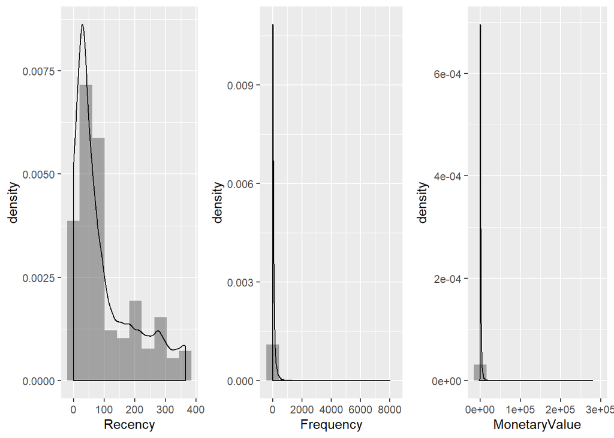

```r
p1 <- datamart %>% ggplot(mapping = aes(x = Recency)) + geom_histogram(aes(y = ..density..), alpha = 0.5, position = "identity", bins = 10) + geom_density(alpha = 0.2)

p2 <- datamart %>% ggplot(mapping = aes(x = Frequency)) + geom_histogram(aes(y = ..density..), alpha = 0.5, position = "identity", bins = 10) + geom_density(alpha = 0.2)

p3 <- datamart %>% ggplot(mapping = aes(x = MonetaryValue)) + geom_histogram(aes(y = ..density..), alpha = 0.5, position = "identity", bins = 10) + geom_density(alpha = 0.2)

grid.arrange(p1, p2, p3, ncol=3)
```

It seems like none of the RFM variables follow the assumptions. Let us transform the data and manage the skew. Since the log only works with positive values so let us remove any negative values from *MonetaryValue* variable. We will also **log transform and standardize the variables** for KMeans clustering.

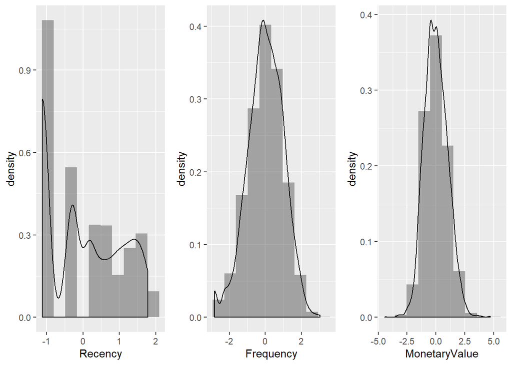

```r
datamart <- datamart %>% filter(MonetaryValue > 0, Recency > 0, Frequency > 0)
#datamart <- datamart %>% mutate(MonetaryValue = MonetaryValue + 1, Recency = Recency + 1, Frequency = Frequency + 1)
datamart <- datamart %>% select(CustomerID, Recency, Frequency, MonetaryValue) %>% mutate(CustomerID = as.character(CustomerID))

# Let us take log of the variables
datamart_log <- datamart %>% mutate(Recency = log(Recency), Frequency = log(Frequency), MonetaryValue = log(MonetaryValue))

# Let us center and scale the log transformed variables
pre_process <- datamart_log %>%  preProcess(., method = c("center","scale"))
datamart_normalized <- predict(pre_process, newdata = datamart_log)

p1 <- datamart_normalized %>% ggplot(mapping = aes(x = Recency)) + geom_histogram(aes(y = ..density..), alpha = 0.5, position = "identity", bins = 10) + geom_density(alpha = 0.2)

p2 <- datamart_normalized %>% ggplot(mapping = aes(x = Frequency)) + geom_histogram(aes(y = ..density..), alpha = 0.5, position = "identity", bins = 10) + geom_density(alpha = 0.2)

p3 <- datamart_normalized %>% ggplot(mapping = aes(x = MonetaryValue)) + geom_histogram(aes(y = ..density..), alpha = 0.5, position = "identity", bins = 10) + geom_density(alpha = 0.2)

grid.arrange(p1, p2, p3, ncol=3)
```